# Power curves for each HR

권대영, 민태원

2023-02-25

## (1) Specification: Choose 16 scenarios (HR, Delta_y)

- N: Number of simulations = 5,000
- n: Number of generated samples per group = 500
- Group2 is treated group
- one-sided, alpha = 0.05, beta = 0 ~ 0.05 (by 0.0005)
- $\Delta_y = \frac{\mu_{y2} - \mu_{y1}}{\sqrt{2}\sigma_{y1}} \in \{0.0, 0.025, 0.05, 0.1\}$ is the primary outcome of interest ($\mu_{y1} = 0$, $\sigma_{y1} = 1$)
- $\begin{pmatrix} Y_1 \\ Y_2 \end{pmatrix} \sim N \begin{pmatrix} \begin{pmatrix} 0\\\sqrt{2} \Delta_y \end{pmatrix}, \begin{pmatrix} \sigma^2_{y1} & \rho_y\sigma_{y1}\sigma_{y2} \\ \rho_y\sigma_{y1}\sigma_{y2} & \sigma^2_{y2} \end{pmatrix} \end{pmatrix}$, $\rho_y=0.8$, $\sigma_{y1}=\sigma_{y2}=1$
- $p_i = E(\delta_{ij}) = \mathrm{Pr}(\delta_{ij}=1) = \mathrm{Pr}(t_{ij} \leq T)$ is the probability of truncated by death at observed time T for group i
- $q_i = 1-p_i = \mathrm{Pr}(t_{ij} > T), \quad i = 1, 2$ is the probability of survival at observed time T
- $q_2 \in \{0.6, 0.8, 0.9\}=\{low, mid, high\}, \quad T = 3$
- $\text{HR(Hazard Ratio)} \in \{1, 1.1, 1.2, 1.3\}$

## (2) Power Simulation

### (a) Survival time follows exponential distribution

#### Power for sequential test

```r
#Define parameters
Delta = c(0.0, 0.025, 0.05, 0.1)
q2 = c(0.6, 0.8, 0.9)
HR = c(1.0, 1.1, 1.2, 1.3)
time = 3
N = 5000
n = 500
rho_t = 0.8
rho_Y = 0.8
alpha = 0.05
beta = seq(0, 0.05, by=5e-4)

simulate.exp.both <- function(n, q2, HR, Delta, time, rho_Y, rho_t){
  lambda2 = -1 / time * log(q2)
  lambda1 = lambda2 * HR
  #q1 = exp(-lambda1 * t)

  corr_t = matrix(c(1, rho_t, rho_t, 1), nrow = 2)
  t = rmvexp(n, rate=c(lambda1, lambda2), corr=corr_t)
  t1 = t[,1]
  t2 = t[,2]

  corr_Y = matrix(c(1, rho_Y, rho_Y, 1), nrow = 2)
  Y = rmvnorm(n, mean = c(0, 2^0.5 * Delta), cov = corr_Y)
  Y1 = Y[,1]
  Y2 = Y[,2]

  eta = min(Y) - 1 - time - 2 *(max(Y)-min(Y)) # in order to be worst
  distmin = min(abs(Y1-Y2))/time/10 # less than minimum difference between Y1 and Y2 divided by time

  Y1_tilde = Y1 * (t1 >= time) + (eta + t1*distmin) * (t1 < time)
  Y2_tilde = Y2 * (t2 >= time) + (eta + t2*distmin) * (t2 < time)

  Y1_survivorOnly = Y1[t1 >= time & t2 >= time]
  Y2_survivorOnly = Y2[t1 >= time & t2 >= time]

  if (length(Y1_survivorOnly) == 0) {
    return (c(-1,-1,-1))
  }

  pval.2 = wilcox.test(Y1_tilde, Y2_tilde, alternative="less", paired=T)$p.value

  OnlyControlDead = sum(t1 < time & t2 >= time)
  OnlyTreatedDead = sum(t2 < time & t1 >= time)
  if (OnlyControlDead == 0 & OnlyTreatedDead == 0) return (c(-1,-1)); # no discordant pair
  pval = binom.test(c(OnlyControlDead, OnlyTreatedDead), alternative = "greater")$p.value;
  if (pval <= alpha) {return (c(pval, pval.2));}
  else {
    if (OnlyTreatedDead == 0) {pval.alt = 0;}
    else {pval.alt = binom.test(c(OnlyControlDead+1, OnlyTreatedDead-1), alternative = "greater")$p.value;}

    if (pval.alt > alpha) { return (c(pval, pval.2)); }
    else {
      return (c(1 - rbinom(1, 1, (alpha - pval.alt)/(pval - pval.alt)), pval.2)); # auxiliary random
    }
  }
}
```

```r
power.exp.seq = array(data = NA, dim=c(length(q2), length(Delta), length(HR), length(beta)), dimnames = list(c("q2=60%", "q2=80%", "q2=90%"), c(0.0, 0.025, 0.05, 0.1), c(1.0, 1.1, 1.2, 1.3), seq(0, 0.05, by=5e-4)))

set.seed(123)
for (i in 1:length(q2)) {
  cat("q2: ", q2[i], "\n")
  for (j in 1:length(Delta)) {
    cat("Delta: ", Delta[j], "\n")
    for (k in 1:length(HR)) {
      cat("HR: ", HR[k], "\n")
      count = array(0, length(beta))
      total = 0
      for (l in c(1:N)) {
        pvals = simulate.exp.both(n, q2[i], HR[k], Delta[j], time, rho_Y, rho_t)
        if (pvals[1] == -1 || pvals[2] == -1) {
          cat("every pairs died at ", l, "-th simluation")
          next;
        }
        total = total + 1
        for (b in 1:length(beta)) {
          if (pvals[1] <= beta[b]) {count[b] = count[b] + 1}
          else if (pvals[2] <= (alpha - beta[b])) {count[b] = count[b] + 1}
        }
      }
      power.exp.seq[i,j,k,] = count/total
    }
  }
}
```

```
## q2:  0.6
## Delta:  0
## HR:  1
## HR:  1.1
## HR:  1.2
## HR:  1.3
## Delta:  0.025
## HR:  1
## HR:  1.1
## HR:  1.2
## HR:  1.3
## Delta:  0.05
## HR:  1
## HR:  1.1
## HR:  1.2
## HR:  1.3
## Delta:  0.1
## HR:  1
## HR:  1.1
## HR:  1.2
## HR:  1.3
## q2:  0.8
## Delta:  0
## HR:  1
## HR:  1.1
## HR:  1.2
## HR:  1.3
## Delta:  0.025
## HR:  1
## HR:  1.1
## HR:  1.2
## HR:  1.3
## Delta:  0.05
## HR:  1
## HR:  1.1
## HR:  1.2
## HR:  1.3
## Delta:  0.1
## HR:  1
## HR:  1.1
```

[output cut: 8 more lines]

```
## Delta:  0.025
## HR:  1
## HR:  1.1
## HR:  1.2
## HR:  1.3
## Delta:  0.05
## HR:  1
## HR:  1.1
## HR:  1.2
## HR:  1.3
## Delta:  0.1
## HR:  1
## HR:  1.1
## HR:  1.2
## HR:  1.3
```

#### plot

```r
exp.seq.q2low = power.exp.seq[1,,,]
exp.seq.q2mid = power.exp.seq[2,,,]
exp.seq.q2high = power.exp.seq[3,,,]
```

##### (1) q2 = low (60%)

```r
power_delta0_hr1.0 = exp.seq.q2low[1,1,] # Delta=0, HR=1
power_delta0_hr1.1 = exp.seq.q2low[1,2,] # Delta=0, HR=1.1
power_delta0_hr1.2 = exp.seq.q2low[1,3,] # Delta=0, HR=1.2
power_delta0_hr1.3 = exp.seq.q2low[1,4,] # Delta=0, HR=1.3

power_delta0.025_hr1.0 = exp.seq.q2low[2,1,] # Delta=0.025, HR=1
power_delta0.025_hr1.1 = exp.seq.q2low[2,2,] # Delta=0.025, HR=1.1
power_delta0.025_hr1.2 = exp.seq.q2low[2,3,] # Delta=0.025, HR=1.2
power_delta0.025_hr1.3 = exp.seq.q2low[2,4,] # Delta=0.025, HR=1.3

power_delta0.05_hr1.0 = exp.seq.q2low[3,1,] # Delta=0.05, HR=1
power_delta0.05_hr1.1 = exp.seq.q2low[3,2,] # Delta=0.05, HR=1.1
power_delta0.05_hr1.2 = exp.seq.q2low[3,3,] # Delta=0.05, HR=1.2
power_delta0.05_hr1.3 = exp.seq.q2low[3,4,] # Delta=0.05, HR=1.3

power_delta0.1_hr1.0 = exp.seq.q2low[4,1,] # Delta=0.1, HR=1
power_delta0.1_hr1.1 = exp.seq.q2low[4,2,] # Delta=0.1, HR=1.1
power_delta0.1_hr1.2 = exp.seq.q2low[4,3,] # Delta=0.1, HR=1.2
power_delta0.1_hr1.3 = exp.seq.q2low[4,4,] # Delta=0.1, HR=1.3

df = data.frame(beta = rep(beta, 16), HR = as.factor(rep(c(1.0, 1.1, 1.2, 1.3), each=4*length(beta))),
                delta = as.factor(rep(rep(c(0, 0.025, 0.05, 0.1), each=length(beta)), 4)), power =
c(power_delta0_hr1.0, power_delta0.025_hr1.0, power_delta0.05_hr1.0, power_delta0.1_hr1.0,
  power_delta0_hr1.1, power_delta0.025_hr1.1, power_delta0.05_hr1.1, power_delta0.1_hr1.1,
  power_delta0_hr1.2, power_delta0.025_hr1.2, power_delta0.05_hr1.2, power_delta0.1_hr1.2,
  power_delta0_hr1.3, power_delta0.025_hr1.3, power_delta0.05_hr1.3, power_delta0.1_hr1.3))

print(df)
```

```
##        beta  HR delta  power
## 1    0.0000   1     0 0.0610
## 2    0.0005   1     0 0.0600
## 3    0.0010   1     0 0.0596
## 4    0.0015   1     0 0.0590
## 5    0.0020   1     0 0.0584
## 6    0.0025   1     0 0.0584
## 7    0.0030   1     0 0.0580
## 8    0.0035   1     0 0.0578
## 9    0.0040   1     0 0.0576
## 10   0.0045   1     0 0.0578
## 11   0.0050   1     0 0.0572
## 12   0.0055   1     0 0.0564
## 13   0.0060   1     0 0.0562
## 14   0.0065   1     0 0.0560
```

[output cut: 1602 more lines]

```r
for (HR in unique(df$HR)) {
  for (delta in unique(df$delta)) {
    gp = df[df$HR==HR & df$delta==delta,]
    max_beta = gp$beta[which(gp$power == max(gp$power))]
    cat("argmax beta for HR", HR, "/ delta", delta, "=", max_beta, "\n")
  }
}
```

```
## argmax beta for HR 1 / delta 0 = 0
## argmax beta for HR 1 / delta 0.025 = 0
## argmax beta for HR 1 / delta 0.05 = 0
## argmax beta for HR 1 / delta 0.1 = 0
## argmax beta for HR 1.1 / delta 0 = 0.0495
## argmax beta for HR 1.1 / delta 0.025 = 0
## argmax beta for HR 1.1 / delta 0.05 = 0
## argmax beta for HR 1.1 / delta 0.1 = 0
## argmax beta for HR 1.2 / delta 0 = 0.0495
## argmax beta for HR 1.2 / delta 0.025 = 0.015 0.0225
## argmax beta for HR 1.2 / delta 0.05 = 0
## argmax beta for HR 1.2 / delta 0.1 = 0 5e-04 0.001 0.0015 0.002 0.0025 0.003 0.0035 0.004 0.0045
## argmax beta for HR 1.3 / delta 0 = 0.0485 0.049 0.0495 0.05
## argmax beta for HR 1.3 / delta 0.025 = 0.03 0.035 0.0355
## argmax beta for HR 1.3 / delta 0.05 = 0 5e-04 0.001 0.0015 0.002 0.0025
## argmax beta for HR 1.3 / delta 0.1 = 0 5e-04 0.001 0.0015 0.002 0.0025 0.003 0.0035 0.004 0.0045 0.005 0.0055 0.006 0.0065 0.007 0.0075 0.008 0.0085 0.009 0.0095 0.01 0.0105 0.011 0.0115 0.012 0.0125 0.013 0.0135 0.014 0.0145 0.015 0.0155 0.016 0.0165 0.017 0.0175 0.018 0.0185 0.019 0.0195 0.02 0…
```

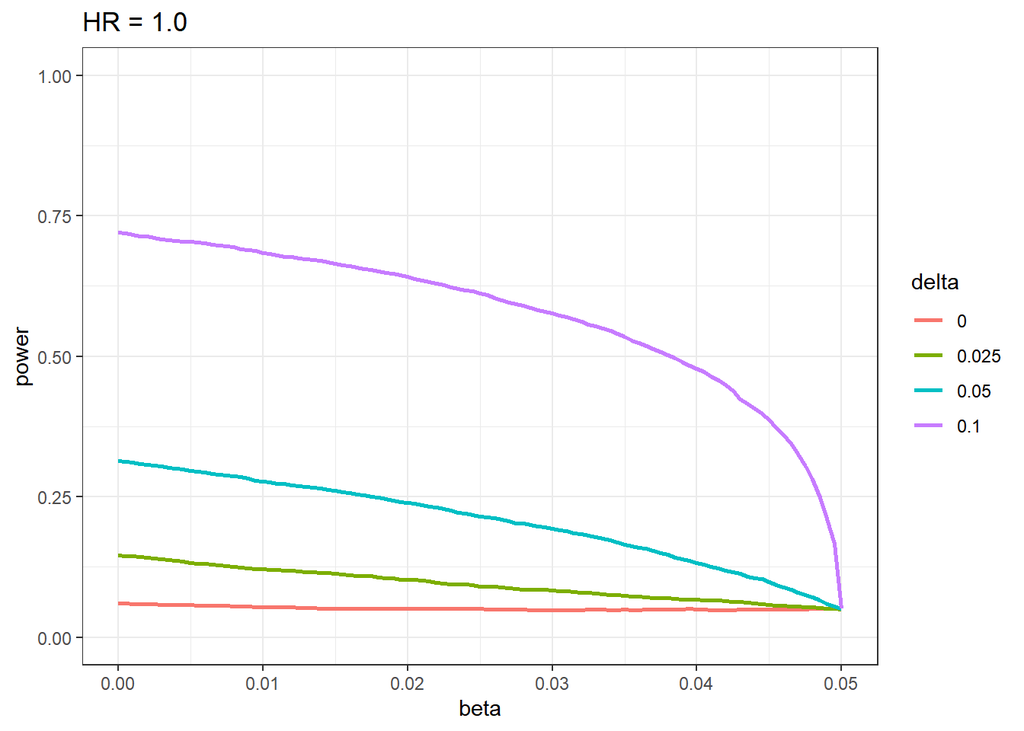

```r
g1.0low <- ggplot(df[df$HR==1.0,], aes(beta, power, col=delta)) +
  geom_line(size=1) +
  theme_bw() +
  scale_y_continuous(limits=c(0, 1)) +
  ggtitle("HR = 1.0")

g1.1low <- ggplot(df[df$HR==1.1,], aes(beta, power, col=delta)) +
  geom_line(size=1) +
  theme_bw() +
  scale_y_continuous(limits=c(0, 1)) +
  ggtitle("HR = 1.1")

g1.2low <- ggplot(df[df$HR==1.2,], aes(beta, power, col=delta)) +
  geom_line(size=1) +
  theme_bw() +
  scale_y_continuous(limits=c(0, 1)) +
  ggtitle("HR = 1.2")

g1.3low <- ggplot(df[df$HR==1.3,], aes(beta, power, col=delta)) +
  geom_line(size=1) +
  theme_bw() +
  scale_y_continuous(limits=c(0.9, 1)) +
  ggtitle("HR = 1.3")

g1.0low
```

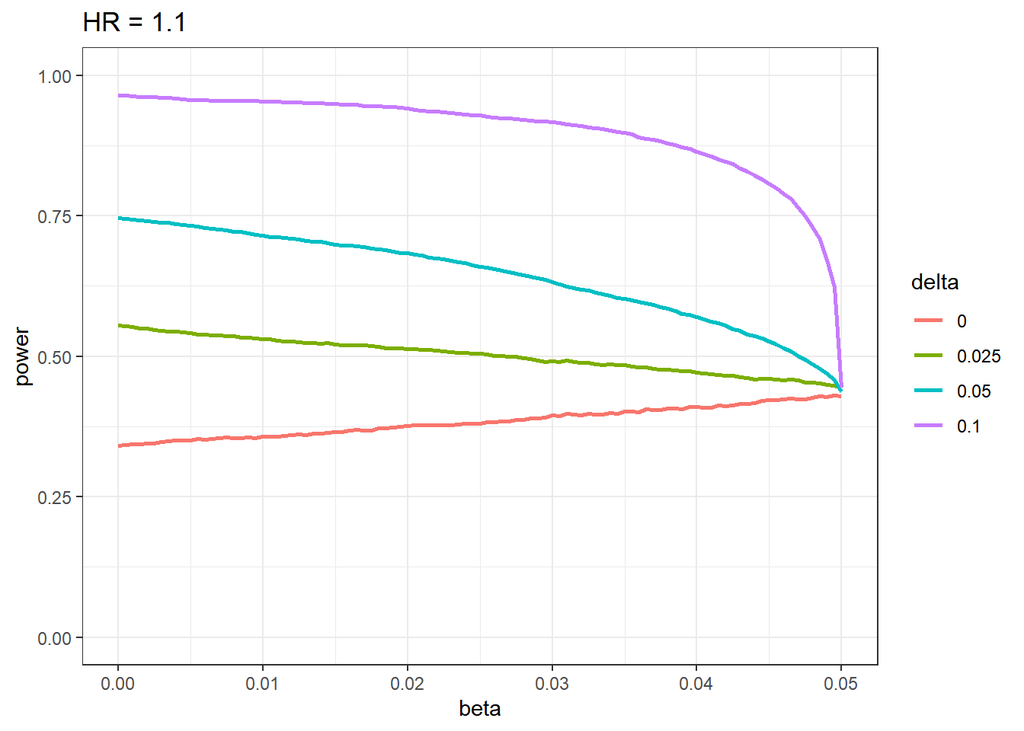

```r
g1.1low
```

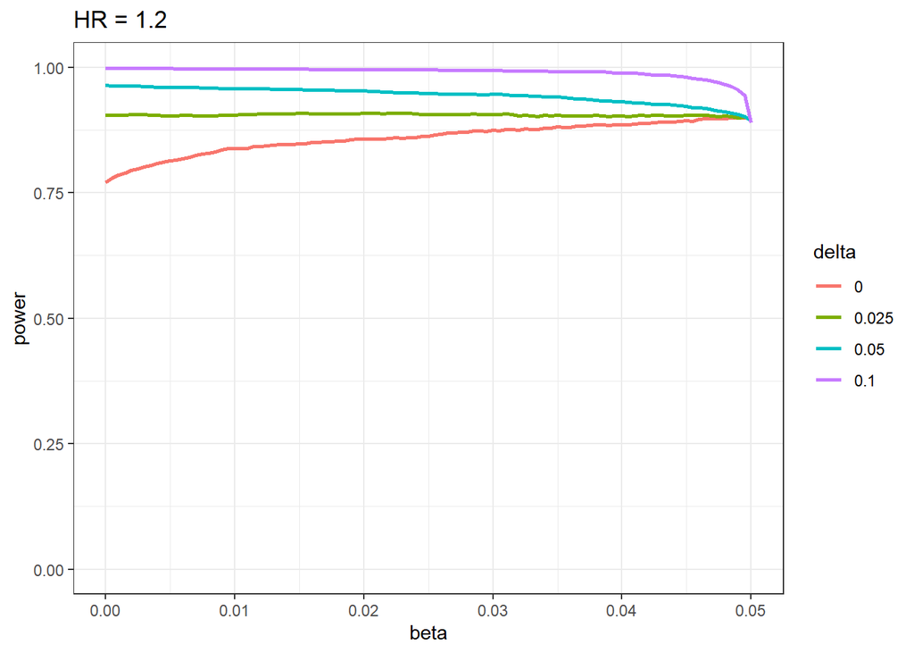

```r
g1.2low
```

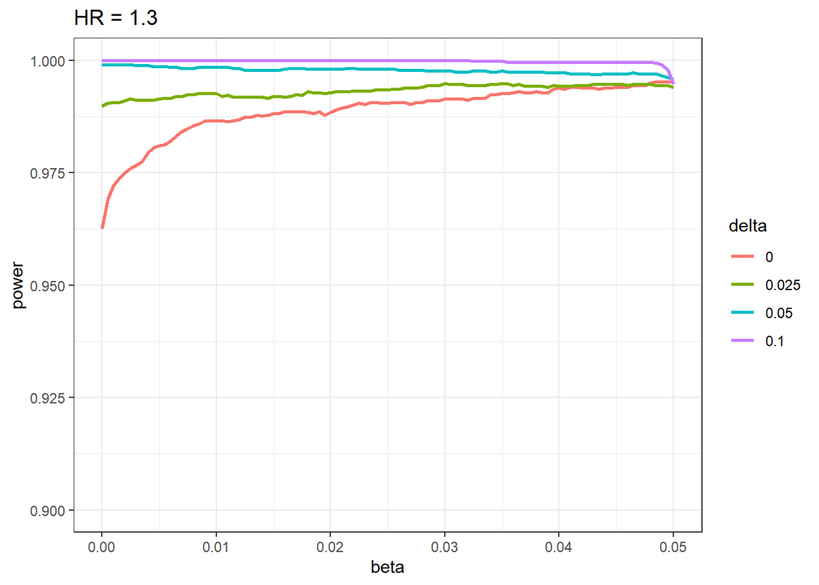

```r
g1.3low
```

##### (2) q2 = mid (80%)

```r
power_delta0_hr1.0 = exp.seq.q2mid[1,1,] # Delta=0, HR=1
power_delta0_hr1.1 = exp.seq.q2mid[1,2,] # Delta=0, HR=1.1
power_delta0_hr1.2 = exp.seq.q2mid[1,3,] # Delta=0, HR=1.2
power_delta0_hr1.3 = exp.seq.q2mid[1,4,] # Delta=0, HR=1.3

power_delta0.025_hr1.0 = exp.seq.q2mid[2,1,] # Delta=0.025, HR=1
power_delta0.025_hr1.1 = exp.seq.q2mid[2,2,] # Delta=0.025, HR=1.1
power_delta0.025_hr1.2 = exp.seq.q2mid[2,3,] # Delta=0.025, HR=1.2
power_delta0.025_hr1.3 = exp.seq.q2mid[2,4,] # Delta=0.025, HR=1.3

power_delta0.05_hr1.0 = exp.seq.q2mid[3,1,] # Delta=0.05, HR=1
power_delta0.05_hr1.1 = exp.seq.q2mid[3,2,] # Delta=0.05, HR=1.1
power_delta0.05_hr1.2 = exp.seq.q2mid[3,3,] # Delta=0.05, HR=1.2
power_delta0.05_hr1.3 = exp.seq.q2mid[3,4,] # Delta=0.05, HR=1.3

power_delta0.1_hr1.0 = exp.seq.q2mid[4,1,] # Delta=0.1, HR=1
power_delta0.1_hr1.1 = exp.seq.q2mid[4,2,] # Delta=0.1, HR=1.1
power_delta0.1_hr1.2 = exp.seq.q2mid[4,3,] # Delta=0.1, HR=1.2
power_delta0.1_hr1.3 = exp.seq.q2mid[4,4,] # Delta=0.1, HR=1.3

df = data.frame(beta = rep(beta, 16), HR = as.factor(rep(c(1.0, 1.1, 1.2, 1.3), each=4*length(beta))),
                delta = as.factor(rep(rep(c(0, 0.025, 0.05, 0.1), each=length(beta)), 4)), power =
c(power_delta0_hr1.0, power_delta0.025_hr1.0, power_delta0.05_hr1.0, power_delta0.1_hr1.0,
  power_delta0_hr1.1, power_delta0.025_hr1.1, power_delta0.05_hr1.1, power_delta0.1_hr1.1,
  power_delta0_hr1.2, power_delta0.025_hr1.2, power_delta0.05_hr1.2, power_delta0.1_hr1.2,
  power_delta0_hr1.3, power_delta0.025_hr1.3, power_delta0.05_hr1.3, power_delta0.1_hr1.3))

print(df)
```

```
##        beta  HR delta  power
## 1    0.0000   1     0 0.0576
## 2    0.0005   1     0 0.0574
## 3    0.0010   1     0 0.0560
## 4    0.0015   1     0 0.0558
## 5    0.0020   1     0 0.0560
## 6    0.0025   1     0 0.0562
## 7    0.0030   1     0 0.0560
## 8    0.0035   1     0 0.0554
## 9    0.0040   1     0 0.0550
## 10   0.0045   1     0 0.0548
## 11   0.0050   1     0 0.0546
## 12   0.0055   1     0 0.0548
## 13   0.0060   1     0 0.0552
## 14   0.0065   1     0 0.0548
```

[output cut: 1602 more lines]

```r
for (HR in unique(df$HR)) {
  for (delta in unique(df$delta)) {
    gp = df[df$HR==HR & df$delta==delta,]
    max_beta = gp$beta[which(gp$power == max(gp$power))]
    cat("argmax beta for HR", HR, "/ delta", delta, "=", max_beta, "\n")
  }
}
```

```
## argmax beta for HR 1 / delta 0 = 0
## argmax beta for HR 1 / delta 0.025 = 0
## argmax beta for HR 1 / delta 0.05 = 0
## argmax beta for HR 1 / delta 0.1 = 0
## argmax beta for HR 1.1 / delta 0 = 0.049
## argmax beta for HR 1.1 / delta 0.025 = 0
## argmax beta for HR 1.1 / delta 0.05 = 0
## argmax beta for HR 1.1 / delta 0.1 = 0
## argmax beta for HR 1.2 / delta 0 = 0.0495
## argmax beta for HR 1.2 / delta 0.025 = 0.0085
## argmax beta for HR 1.2 / delta 0.05 = 0
## argmax beta for HR 1.2 / delta 0.1 = 0
## argmax beta for HR 1.3 / delta 0 = 0.049
## argmax beta for HR 1.3 / delta 0.025 = 0.0415
## argmax beta for HR 1.3 / delta 0.05 = 0
## argmax beta for HR 1.3 / delta 0.1 = 0 5e-04 0.001 0.0015 0.002 0.0025 0.003
```

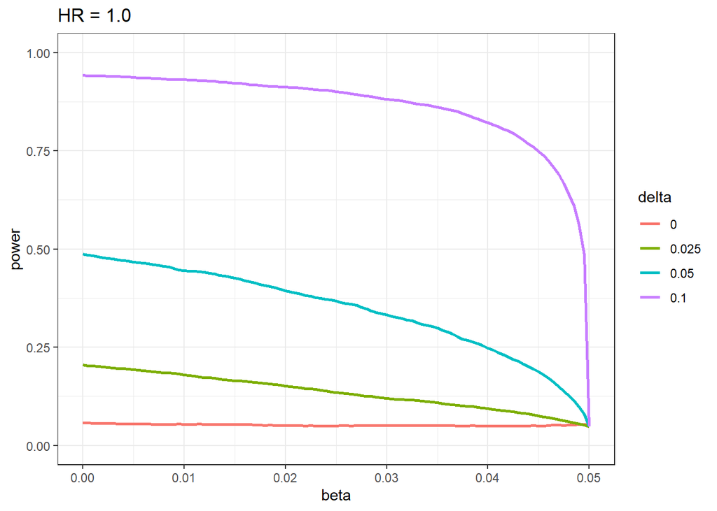

```r
g1.0mid <- ggplot(df[df$HR==1.0,], aes(beta, power, col=delta)) +
  geom_line(size=1) +
  theme_bw() +
  scale_y_continuous(limits=c(0, 1)) +
  ggtitle("HR = 1.0")

g1.1mid <- ggplot(df[df$HR==1.1,], aes(beta, power, col=delta)) +
  geom_line(size=1) +
  theme_bw() +
  scale_y_continuous(limits=c(0, 1)) +
  ggtitle("HR = 1.1")

g1.2mid <- ggplot(df[df$HR==1.2,], aes(beta, power, col=delta)) +
  geom_line(size=1) +
  theme_bw() +
  scale_y_continuous(limits=c(0, 1)) +
  ggtitle("HR = 1.2")

g1.3mid <- ggplot(df[df$HR==1.3,], aes(beta, power, col=delta)) +
  geom_line(size=1) +
  theme_bw() +
  scale_y_continuous(limits=c(0, 1)) +
  ggtitle("HR = 1.3")

g1.0mid
```

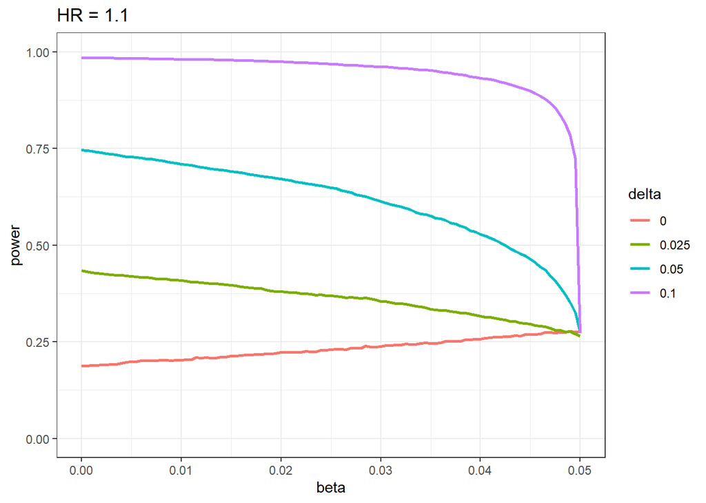

```r
g1.1mid
```

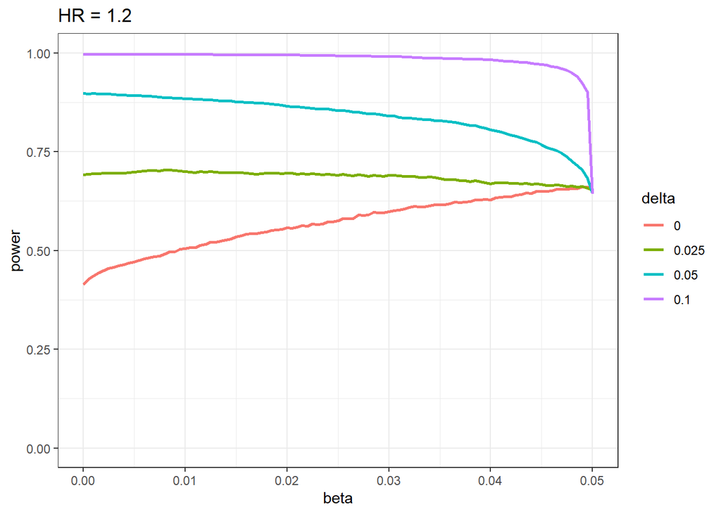

```r
g1.2mid
```

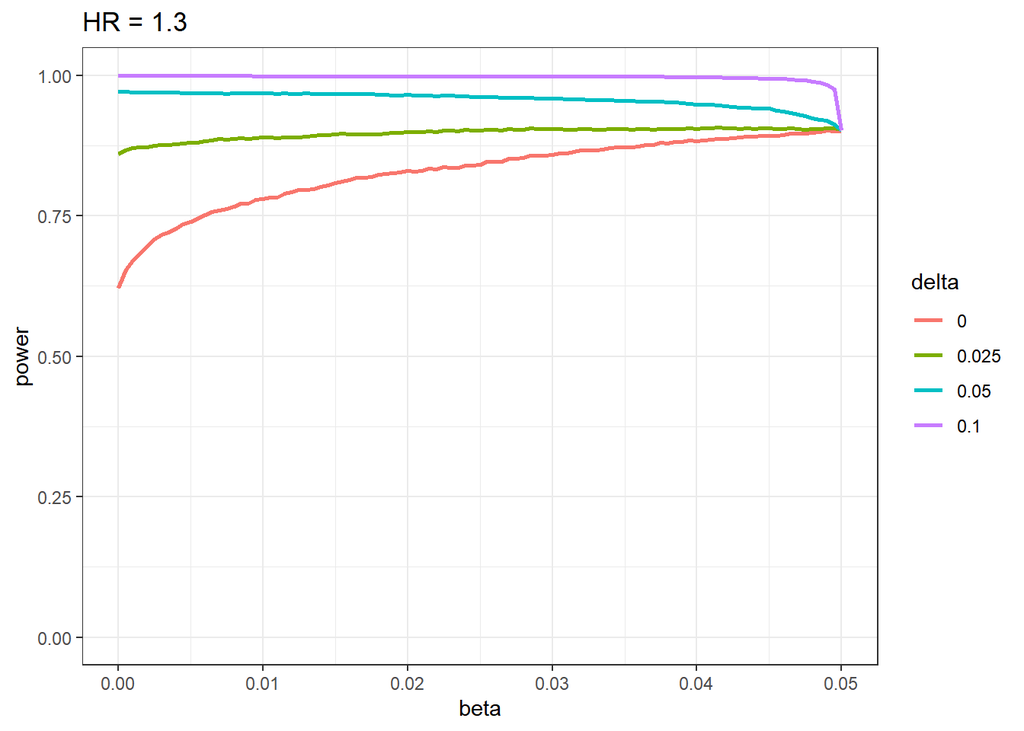

```r
g1.3mid
```

##### (3) q2 = high (90%)

```r
power_delta0_hr1.0 = exp.seq.q2high[1,1,] # Delta=0, HR=1
power_delta0_hr1.1 = exp.seq.q2high[1,2,] # Delta=0, HR=1.1
power_delta0_hr1.2 = exp.seq.q2high[1,3,] # Delta=0, HR=1.2
power_delta0_hr1.3 = exp.seq.q2high[1,4,] # Delta=0, HR=1.3

power_delta0.025_hr1.0 = exp.seq.q2high[2,1,] # Delta=0.025, HR=1
power_delta0.025_hr1.1 = exp.seq.q2high[2,2,] # Delta=0.025, HR=1.1
power_delta0.025_hr1.2 = exp.seq.q2high[2,3,] # Delta=0.025, HR=1.2
power_delta0.025_hr1.3 = exp.seq.q2high[2,4,] # Delta=0.025, HR=1.3

power_delta0.05_hr1.0 = exp.seq.q2high[3,1,] # Delta=0.05, HR=1
power_delta0.05_hr1.1 = exp.seq.q2high[3,2,] # Delta=0.05, HR=1.1
power_delta0.05_hr1.2 = exp.seq.q2high[3,3,] # Delta=0.05, HR=1.2
power_delta0.05_hr1.3 = exp.seq.q2high[3,4,] # Delta=0.05, HR=1.3

power_delta0.1_hr1.0 = exp.seq.q2high[4,1,] # Delta=0.1, HR=1
power_delta0.1_hr1.1 = exp.seq.q2high[4,2,] # Delta=0.1, HR=1.1
power_delta0.1_hr1.2 = exp.seq.q2high[4,3,] # Delta=0.1, HR=1.2
power_delta0.1_hr1.3 = exp.seq.q2high[4,4,] # Delta=0.1, HR=1.3

df = data.frame(beta = rep(beta, 16), HR = as.factor(rep(c(1.0, 1.1, 1.2, 1.3), each=4*length(beta))),
                delta = as.factor(rep(rep(c(0, 0.025, 0.05, 0.1), each=length(beta)), 4)), power =
c(power_delta0_hr1.0, power_delta0.025_hr1.0, power_delta0.05_hr1.0, power_delta0.1_hr1.0,
  power_delta0_hr1.1, power_delta0.025_hr1.1, power_delta0.05_hr1.1, power_delta0.1_hr1.1,
  power_delta0_hr1.2, power_delta0.025_hr1.2, power_delta0.05_hr1.2, power_delta0.1_hr1.2,
  power_delta0_hr1.3, power_delta0.025_hr1.3, power_delta0.05_hr1.3, power_delta0.1_hr1.3))

print(df)
```

```
##        beta  HR delta  power
## 1    0.0000   1     0 0.0514
## 2    0.0005   1     0 0.0506
## 3    0.0010   1     0 0.0504
## 4    0.0015   1     0 0.0502
## 5    0.0020   1     0 0.0504
## 6    0.0025   1     0 0.0500
## 7    0.0030   1     0 0.0498
## 8    0.0035   1     0 0.0496
## 9    0.0040   1     0 0.0494
## 10   0.0045   1     0 0.0488
## 11   0.0050   1     0 0.0484
## 12   0.0055   1     0 0.0482
## 13   0.0060   1     0 0.0476
## 14   0.0065   1     0 0.0468
```

[output cut: 1602 more lines]

```r
for (HR in unique(df$HR)) {
  for (delta in unique(df$delta)) {
    gp = df[df$HR==HR & df$delta==delta,]
    max_beta = gp$beta[which(gp$power == max(gp$power))]
    cat("argmax beta for HR", HR, "/ delta", delta, "=", max_beta, "\n")
  }
}
```

```
## argmax beta for HR 1 / delta 0 = 0
## argmax beta for HR 1 / delta 0.025 = 0
## argmax beta for HR 1 / delta 0.05 = 0
## argmax beta for HR 1 / delta 0.1 = 0 5e-04
## argmax beta for HR 1.1 / delta 0 = 0.0495 0.05
## argmax beta for HR 1.1 / delta 0.025 = 0
## argmax beta for HR 1.1 / delta 0.05 = 0
## argmax beta for HR 1.1 / delta 0.1 = 0 5e-04 0.001
## argmax beta for HR 1.2 / delta 0 = 0.0495
## argmax beta for HR 1.2 / delta 0.025 = 5e-04
## argmax beta for HR 1.2 / delta 0.05 = 0
## argmax beta for HR 1.2 / delta 0.1 = 0 5e-04 0.001 0.0015
## argmax beta for HR 1.3 / delta 0 = 0.0495
## argmax beta for HR 1.3 / delta 0.025 = 0.0275
## argmax beta for HR 1.3 / delta 0.05 = 5e-04 0.001
## argmax beta for HR 1.3 / delta 0.1 = 0 5e-04 0.001 0.0015 0.002 0.0025 0.003 0.0035
```

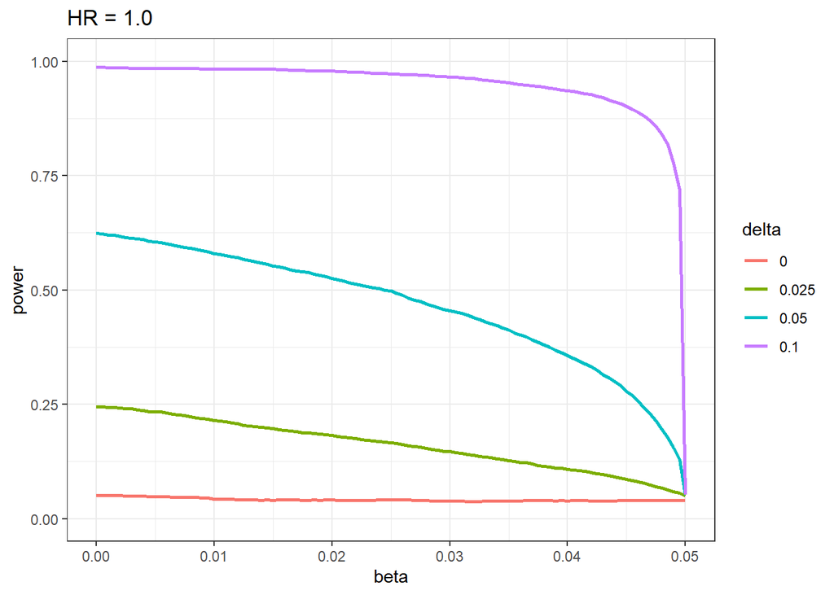

```r
g1.0high <- ggplot(df[df$HR==1.0,], aes(beta, power, col=delta)) +
  geom_line(size=1) +
  theme_bw() +
  scale_y_continuous(limits=c(0, 1)) +
  ggtitle("HR = 1.0")

g1.1high <- ggplot(df[df$HR==1.1,], aes(beta, power, col=delta)) +
  geom_line(size=1) +
  theme_bw() +
  scale_y_continuous(limits=c(0, 1)) +
  ggtitle("HR = 1.1")

g1.2high <- ggplot(df[df$HR==1.2,], aes(beta, power, col=delta)) +
  geom_line(size=1) +
  theme_bw() +
  scale_y_continuous(limits=c(0, 1)) +
  ggtitle("HR = 1.2")

g1.3high <- ggplot(df[df$HR==1.3,], aes(beta, power, col=delta)) +
  geom_line(size=1) +
  theme_bw() +
  scale_y_continuous(limits=c(0, 1)) +
  ggtitle("HR = 1.3")

g1.0high
```

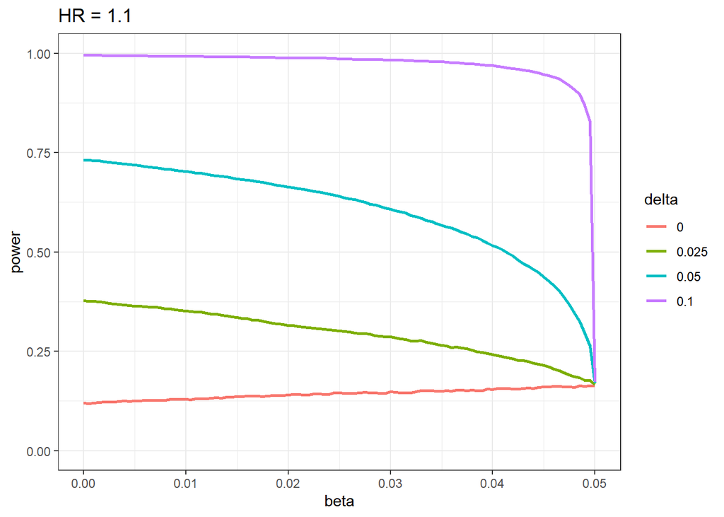

```r
g1.1high
```

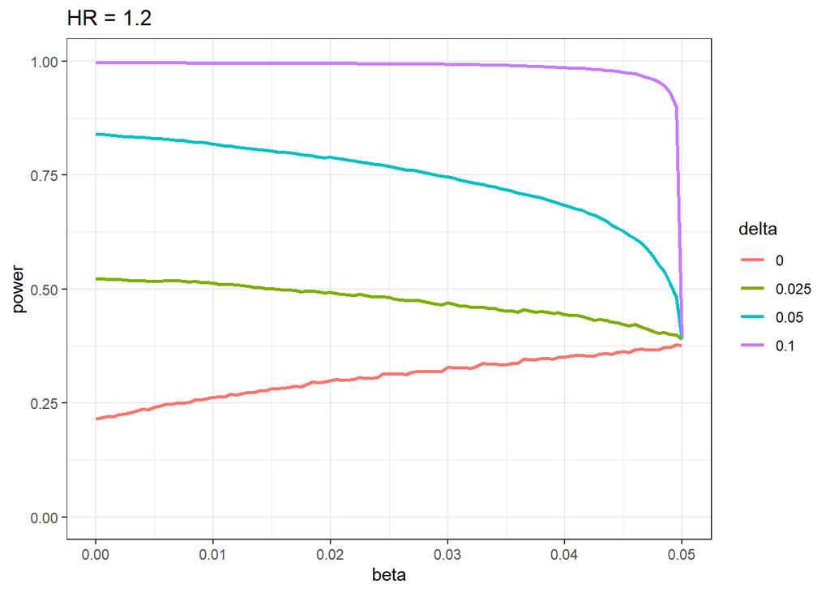

```r
g1.2high
```

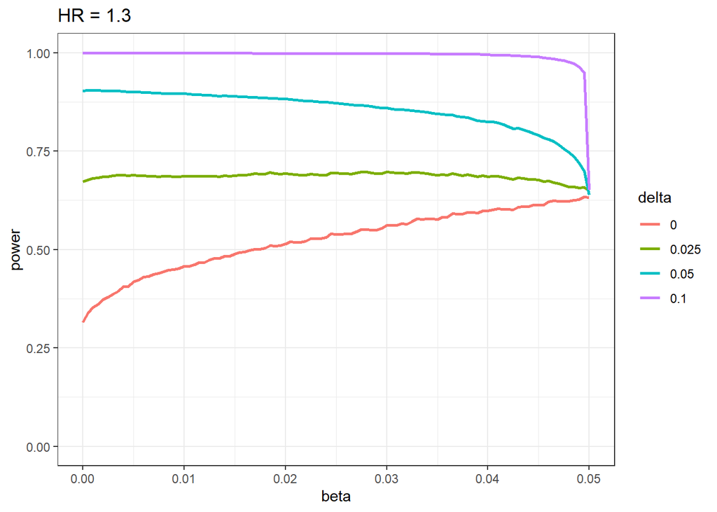

```r
g1.3high
```

### Plot at once

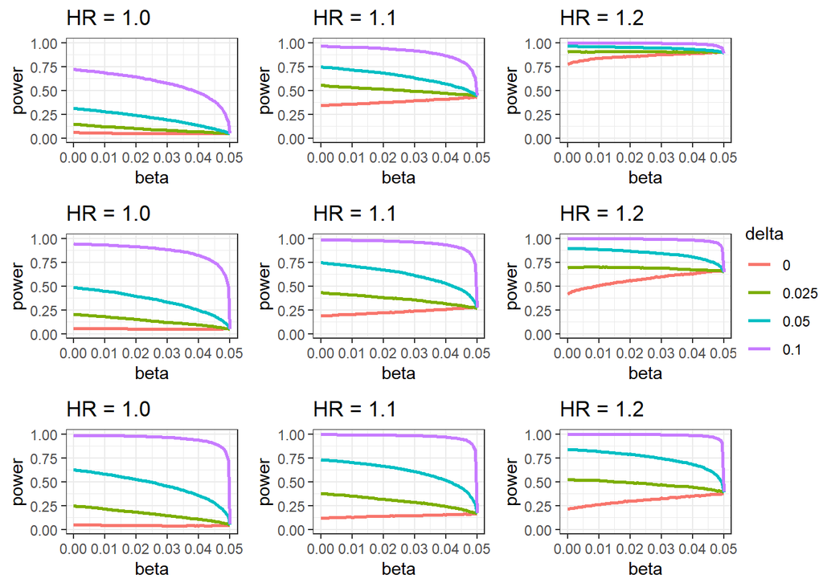

```r
extract_legend <- function(my_ggp) {
  step1 <- ggplot_gtable(ggplot_build(my_ggp))
  step2 <- which(sapply(step1$grobs, function(x) x$name) == "guide-box")
  step3 <- step1$grobs[[step2]]
  return(step3)
}
shared_legend <- extract_legend(g1.0high)

g1.0low <- g1.0low + theme(legend.position="none")
g1.1low <- g1.1low + theme(legend.position="none")
g1.2low <- g1.2low + theme(legend.position="none")
g1.3low <- g1.3low + theme(legend.position="none")
g1.0mid <- g1.0mid + theme(legend.position="none")
g1.1mid <- g1.1mid + theme(legend.position="none")
g1.2mid <- g1.2mid + theme(legend.position="none")
g1.3mid <- g1.3mid + theme(legend.position="none")
g1.0high <- g1.0high + theme(legend.position="none")
g1.1high <- g1.1high + theme(legend.position="none")
g1.2high <- g1.2high + theme(legend.position="none")
g1.3high <- g1.3high + theme(legend.position="none")

grid.arrange(g1.0low, g1.1low, g1.2low, g1.0mid, g1.1mid, g1.2mid, g1.0high, g1.1high, g1.2high, shared_legend, ncol=4,
             widths=c(3,3,3,1), layout_matrix=cbind(c(1,4,7), c(2,5,8), c(3,6,9), c(10,10,10)))
```